# **Mall Customer Segmentation report**

Subhajit Karmakar

2023-12-26

The data given to us contains information on customers in a particular supermarket. There are 5 variables in total. Our goal is to group the similar customers using **K-means** algorithm, based on the their purchase behavior.

**Data source:** https://www.kaggle.com/datasets/vjchoudhary7/customer-segmentation-tutorial-in-python

> **Necessary libraries & data importation**

```r
library(tidyverse)
library(factoextra)
library(kableExtra)

df <- read_csv('D:/Internships/Prodigy/Task 2 (Clustering)/Data2.csv',
               show_col_types = F)
```

> **Glimpse at the data**

```
## Rows: 200
## Columns: 5
## $ CustomerID               <dbl> 1, 2, 3, 4, 5, 6, 7, 8, 9, 10, 11, 12, 13, 14…
## $ Gender                   <chr> "Male", "Male", "Female", "Female", "Female",…
## $ Age                      <dbl> 19, 21, 20, 23, 31, 22, 35, 23, 64, 30, 67, 3…
## $ `Annual Income (k$)`     <dbl> 15, 15, 16, 16, 17, 17, 18, 18, 19, 19, 19, 1…
## $ `Spending Score (1-100)` <dbl> 39, 81, 6, 77, 40, 76, 6, 94, 3, 72, 14, 99, …
```

**Comment:** There are $\small 200$ rows and $\small 5$ columns in the data.

**Checking for missing value**

```r
df %>% is.na() %>% sum()
```

```
## [1] 0
```

$\small \therefore$ There is no missing value in the data.

**Summary statistics**

```
##    CustomerID        Gender               Age        Annual Income (k$)
##  Min.   :  1.00   Length:200         Min.   :18.00   Min.   : 15.00
##  1st Qu.: 50.75   Class :character   1st Qu.:28.75   1st Qu.: 41.50
##  Median :100.50   Mode  :character   Median :36.00   Median : 61.50
##  Mean   :100.50                      Mean   :38.85   Mean   : 60.56
##  3rd Qu.:150.25                      3rd Qu.:49.00   3rd Qu.: 78.00
##  Max.   :200.00                      Max.   :70.00   Max.   :137.00
##  Spending Score (1-100)
##  Min.   : 1.00
##  1st Qu.:34.75
##  Median :50.00
##  Mean   :50.20
##  3rd Qu.:73.00
##  Max.   :99.00
```

Here our task is to perform cluster analysis and we have two variables, first one is `CustomerID`, second one is `Gender` - IDs of customers is not useful in kmeans and gender is categorical variable, which we can not use in kmeans. So, we will ignore the `CustomerID` variable and will not analyze `Gender` variable too much.

> **Univariate Analysis**

Plots to be used:

- **Categorical:** Count-Plot $\big{[}$Variables: `Gender`$\big{]}$
- **Continuous/Numerical:** Histogram $\big{[}$Variables: `Annual Income (k$)`, `Age`, `Spending Score (1-100)`$\big{]}$

**Distribution of Gender**

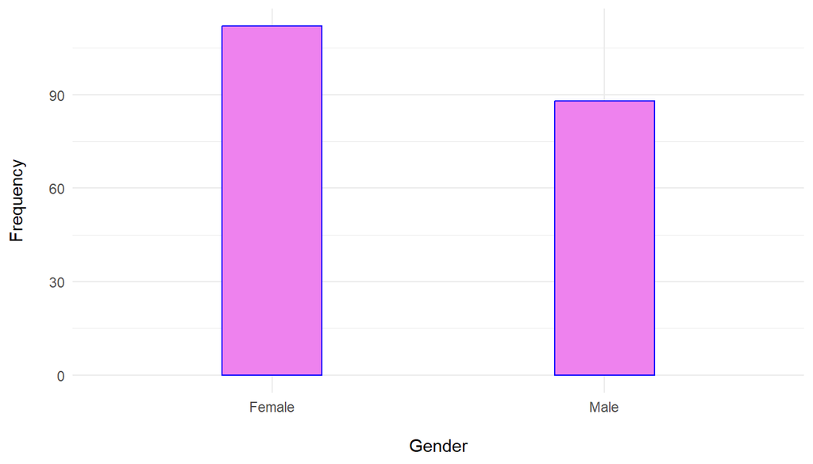

**Distribution of Age**

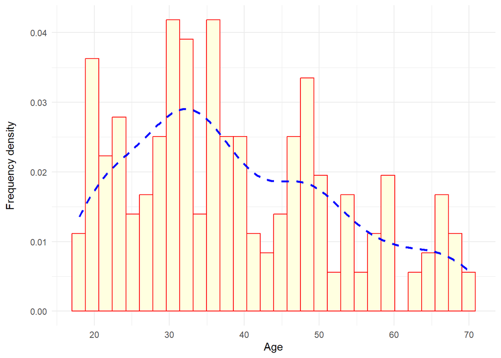

**Distribution of Annual Income**

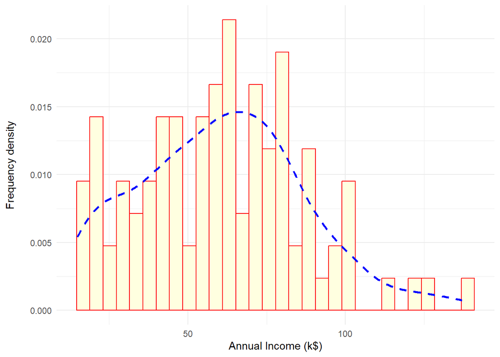

**Distribution of Spending Score**

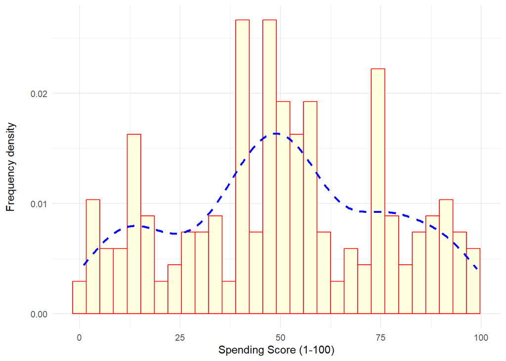

> **Bivariate Analysis**

Plot to be used: Scatter-Plot and Contour-Plot.

Here we are using contour plot to get an idea about the presence of clusters or peaks in the bivariate distributions of variables taking two at a time from the 3.

**Plot 1: Distribution of Age and Annual Income**

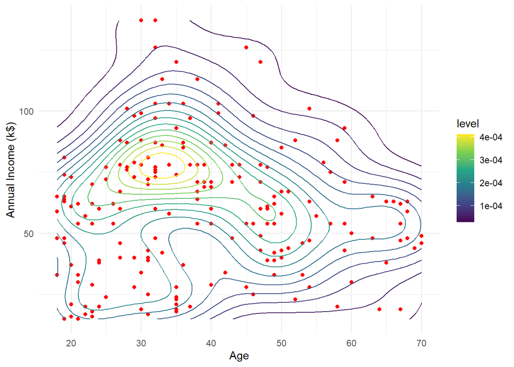

**Comment:** The plot is not so clear, it is roughly indicating 1 peak.

**Plot 2: Distribution of Age and Spending Score**

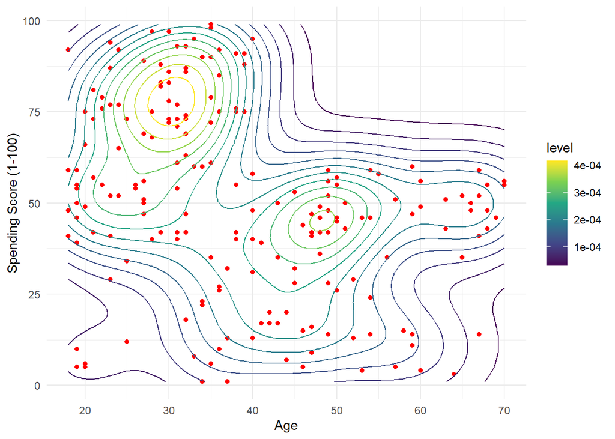

**Comment:** This plot is more clear than the previous one, two peaks are clear in the joint distribution.

**Plot 3: Distribution of Spending Score and Annual Income**

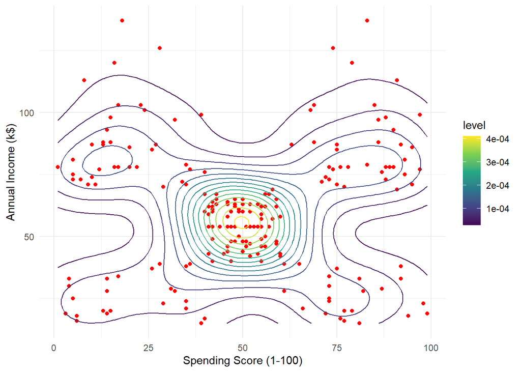

**Comment:** Clear indication of 5 clusters is there.

> **K-means Clustering**

Now that we are done with the EDA, we now proceed with the KMeans clustering. Since Euclidean distance is used here to calculate the distance of the points from the centroids, this algorithm is sensitive to the scale of the data, for that we first scale the data. Also, we have to omit the `CustomerID` and `Gender` from the data (reason mentioned earlier).

- **Scaling method:** StandardScalar

```r
df %>% select(-c(CustomerID, Gender)) %>%
  scale() %>% as_tibble() -> df_active
```

First few rows of the Transformed data

| Age | Annual Income (k$) | Spending Score (1-100) |
| --- | --- | --- |
| -1.4210029 | -1.734646 | -0.4337131 |
| -1.2778288 | -1.734646 | 1.1927111 |
| -1.3494159 | -1.696572 | -1.7116178 |
| -1.1346547 | -1.696572 | 1.0378135 |
| -0.5619583 | -1.658499 | -0.3949887 |

- Note that, `df_active` will be used for the clustering.

**Optimum number of Clusters**

Now, we have to find the optimum number of clusters which suits the data. We will consider different number of clusters and for that number of clusters after which the *within sum of squares* of the clusters will not decrease significantly, will be considered as the optimum number of clusters.

- Consider the following code for the implementation of the above task

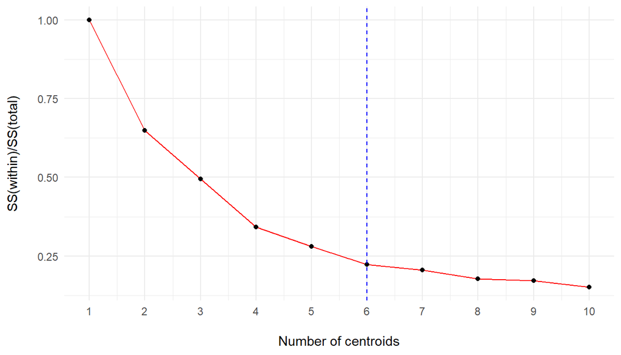

```r
centers <- 1:10
r <- 0

for(i in 1:length(centers)){
  set.seed(42)
  k <- kmeans(df_active, centers[i])
  r[i] <- k$tot.withinss/k$totss
}

ggplot(NULL, aes(x = centers, y = r)) +
  geom_line(colour = 'red') + geom_point() +
  geom_vline(xintercept = 6, lty = 2, colour = 'blue') +
  theme_minimal() +
  labs(x = '\nNumber of centroids', y = 'SS(within)/SS(total)\n') +
  scale_x_continuous(n.breaks = 10)
```

**Comment:** So the optimum number of clusters we consider is 6. So, finally we go with 6 clusters and here $\small \dfrac{\text{Between Sum of Square}}{\text{Total Sum of Square}} = 0.78$

**Final Grouping**

```r
set.seed(42)

K <- kmeans(df_active, centers = 6)
df %>% mutate('Clusters' = K$cluster) -> df
```

The **centroids** of the clusters are listed below:

Cluster centroids

| Age | Annual Income (k$) | Spending Score (1-100) |
| --- | --- | --- |
| -0.9735839 | -1.3221791 | 1.0345865 |
| 1.2515802 | -0.2396117 | -0.0438876 |
| 0.2211606 | 1.0805138 | -1.2868231 |
| 0.4777583 | -1.3049552 | -1.1934487 |
| -0.4408110 | 0.9891010 | 1.2364001 |
| -0.8709130 | -0.1135003 | -0.0933461 |

**Cluster Visualization**

The clusters along with the customer IDs are shown below, from this one can get an idea about the status of the customers belonging to different groups/clusters.

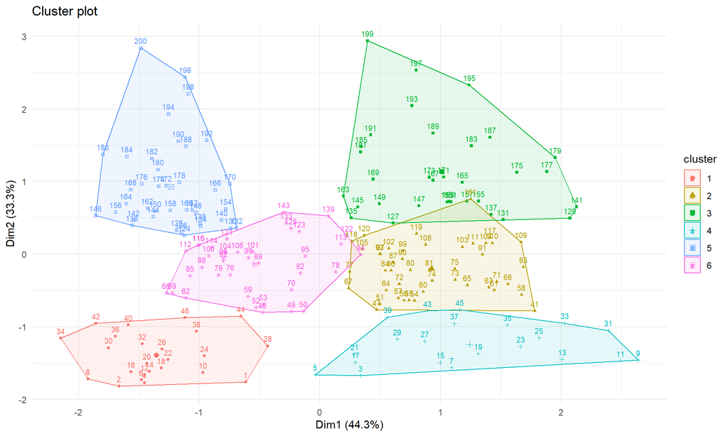

```r
fviz_cluster(K, data = df_active,
             pointsize = 1, labelsize = 8,
             ellipse.alpha = 0.1) +
  theme_minimal()
```

**Thank You!**